# ST 503 Hw 2

Robin Baldeo

### Question 1(Exercise 3.1 in LMR)

### (A)

```r
#full model
lmod<-lm(lpsa~lcavol+lweight+age+lbph+ svi+lcp+ gleason+ pgg45, data=prostate )

#summary
summary(lmod)
```

```
##
## Call:
## lm(formula = lpsa ~ lcavol + lweight + age + lbph + svi + lcp +
##     gleason + pgg45, data = prostate)
##
## Residuals:
##     Min      1Q  Median      3Q     Max
## -1.7331 -0.3713 -0.0170  0.4141  1.6381
##
## Coefficients:
##              Estimate Std. Error t value Pr(>|t|)
## (Intercept)  0.669337   1.296387   0.516  0.60693
## lcavol       0.587022   0.087920   6.677 2.11e-09 ***
## lweight      0.454467   0.170012   2.673  0.00896 **
## age         -0.019637   0.011173  -1.758  0.08229 .
## lbph         0.107054   0.058449   1.832  0.07040 .
## svi          0.766157   0.244309   3.136  0.00233 **
## lcp         -0.105474   0.091013  -1.159  0.24964
## gleason      0.045142   0.157465   0.287  0.77503
## pgg45        0.004525   0.004421   1.024  0.30886
## ---
## Signif. codes:  0 '***' 0.001 '**' 0.01 '*' 0.05 '.' 0.1 ' ' 1
##
## Residual standard error: 0.7084 on 88 degrees of freedom
## Multiple R-squared:  0.6548, Adjusted R-squared:  0.6234
## F-statistic: 20.86 on 8 and 88 DF,  p-value: < 2.2e-16
```

```r
#a
#at the 90% Ci reject Ho because 0 is not within the interval
confint(lmod, "age", level=.90)
```

```
##            5 %         95 %
## age -0.0382102 -0.001064151
```

```r
#at the 95% Ci fail to reject H0 becuause 0 is within interval
confint(lmod, "age")
```

```
##           2.5 %      97.5 %
## age -0.04184062 0.002566267
```

At the 90% level we reject the null hypothesis of age being insignificant because 0 is not within the CI, However, at 95% level we fail to reject the null because 0 is within the interval. This also corresponds to the p-value for age in the summary output. Age p-value is greater than .05 because of this we fail to reject the null.So Both the summary ouput p-value and Ci at the 95% level gives the same conclusion.

### (B)

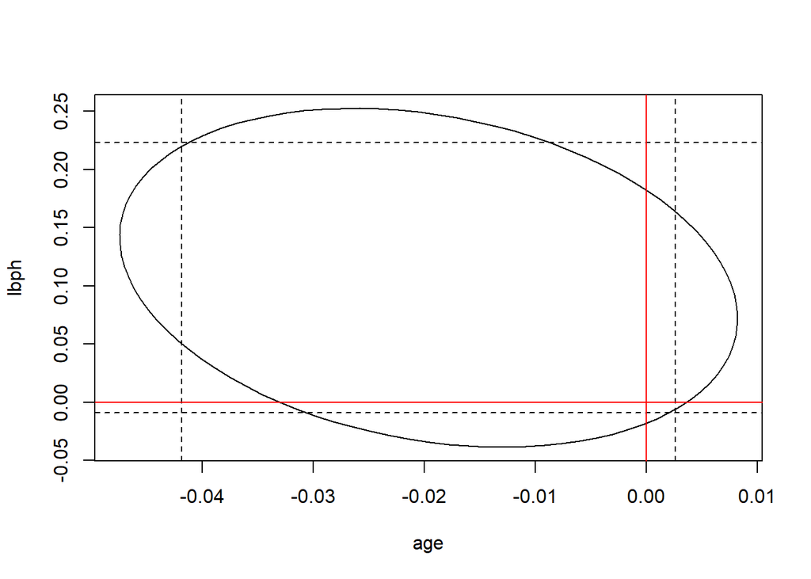

```r
ci<-confint(lmod)
#ellipse
plot(ellipse(lmod, c(4,5)), type = "l")
#CI
abline(v=ci[4,], h=ci[5,], lty=2)
#marking orgin with red lines
abline(h= 0, v = 0, col = "red")
```

```r
#partial f test to confirm
lmodR<-lm(lpsa~lcavol+lweight+ svi+lcp+ gleason+ pgg45, data = prostate)
anova(lmodR, lmod)
```

|  | Res.Df | RSS | Df | Sum of Sq | F | Pr(>F) |
| --- | --- | --- | --- | --- | --- | --- |
| 1 | 90 | 46.76777 | NA | NA | NA | NA |
| 2 | 88 | 44.16302 | 2 | 2.60475 | 2.595135 | 0.08034012 |

Here we fail to reject the null because the origin(red lines) falls within the ellipse. Therefore, these variables age and ibph can be removed from the model because of no significant contribution to the quality of the model.This is also confirmed with a partial f-test. Here p-value> .05 confirming that the values age and lbph don’t contribute to the model in a significant way.

### (C)

```r
set.seed(123)
n<- 10000

ttest<-numeric(n)

#looping n times
for(i in 1:n){
  #storing all t values into the ttest vector
  ttest[i]= (summary(lm(lpsa~lcavol+lweight+sample(age)+lbph+ svi+lcp+ gleason+ pgg45, data=prostate )))$coefficients[4,3]
}

#simulated p-valu for t-test
2 * mean(ttest<summary(lmod)$coefficients[4,3])
```

```
## [1] 0.0778
```

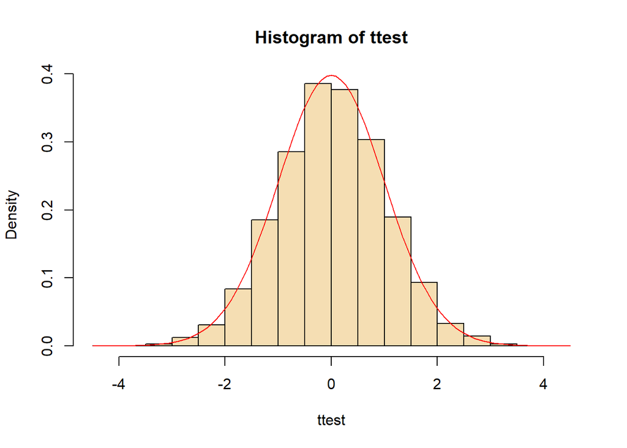

```r
hist(ttest, freq = F, col = "wheat")
x<-ttest
curve(dt(x, length(x)), add=TRUE, col = "red")
```

The permutation method corresponds to the p-value from the summary output. The simulated p-value for age is 0.0778 which closely matches the summary value of 0.0822932.

### Question 2(Exercise 3.5 on page 50 of LMR.)

From class lecture notes:
$$R^2 = 1- \frac{\sum_{i= 1}^{n} (y_i- \hat{y_i})^ 2}{\sum_{i= 1}^{n} (y_i- \bar{y_i})^ 2}$$

$$\begin{aligned}
&F= \frac{n-p}{p-1} \times \frac{TSS-RSS}{RSS}\\
&F \times \frac{p-1}{n-p} = \frac{TSS-RSS}{RSS}\\
&F \times \frac{p-1}{n-p} = \frac{TSS}{RSS} - 1\\
&F \times \frac{p-1}{n-p} + 1 = (1-R^2)^{-1}\\
&(F \times \frac{p-1}{n-p} + 1)^{-1} = 1-R^2 \\
&R^2= 1-(F \times \frac{p-1}{n-p} + 1)^{-1}
\end{aligned}$$

### Question 3(Exercise 3.7 on page 50 of LMR)

### (A)

```r
lmodD<-lm(Distance~RStr + LStr+ RFlex + LFlex, data= punting)
summary(lmodD)$coefficients
```

```
##                Estimate Std. Error    t value  Pr(>|t|)
## (Intercept) -79.6236456 65.5935321 -1.2138948 0.2594050
## RStr          0.5116373  0.4855691  1.0536859 0.3228080
## LStr         -0.1861996  0.5129643 -0.3629875 0.7260179
## RFlex         2.3745010  1.4373549  1.6519935 0.1371390
## LFlex        -0.5277338  0.8255156 -0.6392778 0.5405109
```

```r
#none
```

none of the variables in the model are significant at 5% level.

### (B)

```r
f<- summary(lmodD)$fstat
1- pf(f[1], f[2], f[3])
```

```
##      value
## 0.01902482
```

we reject the null in favour of the alternative where at least one coefficient is non zero because p-value = 0.0190248) <.05.

### (C)

```r
lmodDR<-lm(Distance~I(RStr + LStr)+ RFlex + LFlex, data = punting)
summary(lmodDR)
```

```
##
## Call:
## lm(formula = Distance ~ I(RStr + LStr) + RFlex + LFlex, data = punting)
##
## Residuals:
##     Min      1Q  Median      3Q     Max
## -21.698  -9.494  -5.155   9.081  20.611
##
## Coefficients:
##                Estimate Std. Error t value Pr(>|t|)
## (Intercept)    -71.2694    63.1447  -1.129    0.288
## I(RStr + LStr)   0.1741     0.1940   0.898    0.393
## RFlex            2.3137     1.4013   1.651    0.133
## LFlex           -0.5772     0.8035  -0.718    0.491
##
## Residual standard error: 15.94 on 9 degrees of freedom
## Multiple R-squared:  0.7174, Adjusted R-squared:  0.6232
## F-statistic: 7.615 on 3 and 9 DF,  p-value: 0.00769
```

```r
anova(lmodDR, lmodD)
```

|  | Res.Df | RSS | Df | Sum of Sq | F | Pr(>F) |
| --- | --- | --- | --- | --- | --- | --- |
| 1 | 9 | 2287.356 | NA | NA | NA | NA |
| 2 | 8 | 2132.641 | 1 | 154.7151 | 0.5803702 | 0.4680292 |

### (D)

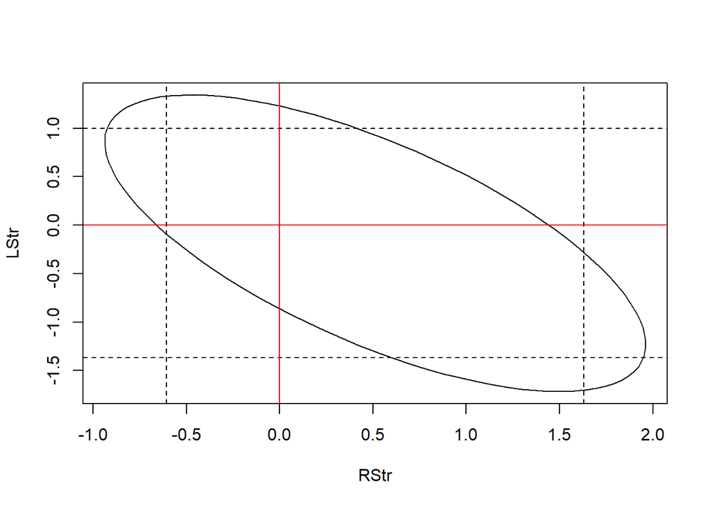

```r
ci <- confint(lmodD)
plot(ellipse(lmodD, c(2,3)), type ="l")
abline(h =ci[3,], v = ci[2,], lty = 2 )
abline(h= 0, v = 0, col = "red")
```

```r
lmodDR1<-lm(Distance~ RFlex + LFlex, data = punting)
anova(lmodDR1, lmodD)
```

|  | Res.Df | RSS | Df | Sum of Sq | F | Pr(>F) |
| --- | --- | --- | --- | --- | --- | --- |
| 1 | 10 | 2492.101 | NA | NA | NA | NA |
| 2 | 8 | 2132.641 | 2 | 359.4606 | 0.6742075 | 0.5363003 |

We fail to reject the null of B1_rstr=B2_lstr= 0. Because the origin falls within the ellipse. Since our test in c shows that RStr + LStr has the same effect as using the variables separately. We see from the test above that the two variables separately or combined might not have any significant contribution to the reponse. This is also confirmed with a partial f-test where p-values > .05.

### Question 4

### (A)

```r
set.seed(123)

nr <- nrow(teengamb)

teen <-teengamb

teen$y <- rnorm(nr)


model<-lm(y~sex + status + income+ verbal, data = teen)
summary(model)
```

```
##
## Call:
## lm(formula = y ~ sex + status + income + verbal, data = teen)
##
## Residuals:
##      Min       1Q   Median       3Q      Max
## -2.06932 -0.65108  0.00983  0.65841  2.17125
##
## Coefficients:
##             Estimate Std. Error t value Pr(>|t|)
## (Intercept) -0.50355    0.73584  -0.684    0.498
## sex          0.43498    0.35135   1.238    0.223
## status       0.01191    0.01203   0.990    0.328
## income       0.01404    0.04388   0.320    0.751
## verbal      -0.03669    0.09295  -0.395    0.695
##
## Residual standard error: 0.9709 on 42 degrees of freedom
## Multiple R-squared:  0.03865,    Adjusted R-squared:  -0.05291
## F-statistic: 0.4221 on 4 and 42 DF,  p-value: 0.7918
```

We would fail to reject the null because the p-value > .05.

### (B)

```r
set.seed(123)

B <- 5000
x <- numeric(B)

for(b in 1:B) {
  teen <-teengamb
  teen$y <- rnorm(nr)
  o.full<-lm(y~sex + status + income+ verbal, data = teen)
  x[b]<- summary(o.full)$fstat[1]

}
```

### (C)

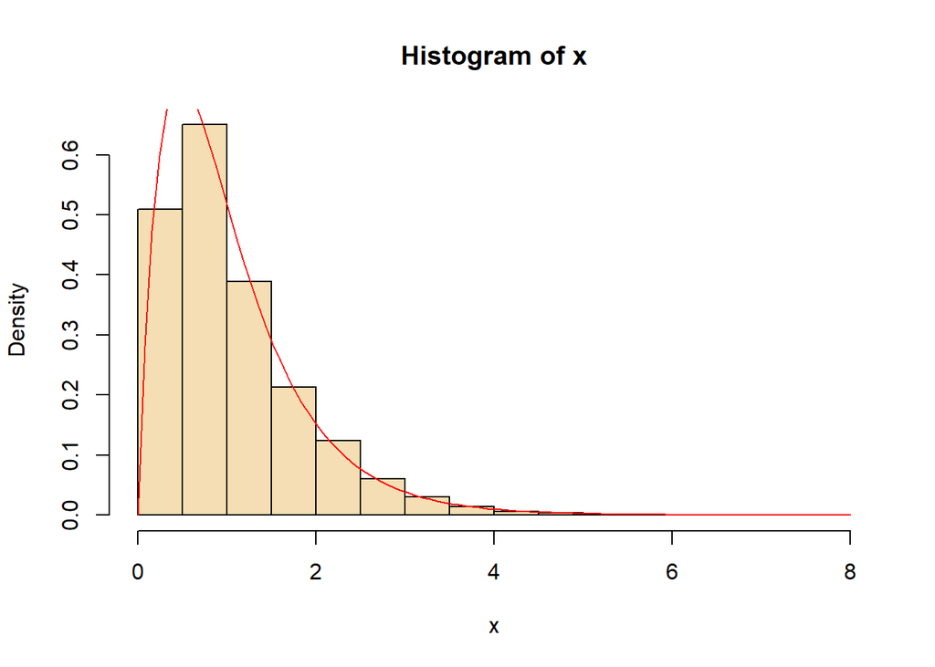

```r
hist(x, freq=F, col= "wheat" )
curve(df(x, 4, 42), add = T, col = "red")
```

Yes, the claim is true, the plot proves that the simulation of the 5000 f plotted gives the f-distribution.